# STA426 Exercise Week 14

## Segmentation example

Here, we make a toy example of some data with changepoints, in order to play around with the circular binary segmentation method. Here is a short pipeline:

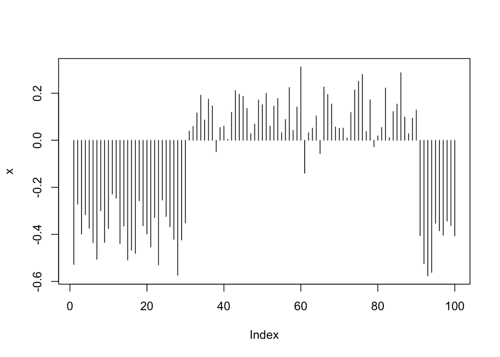

```r
n <- 100
x <- rnorm(n, sd=0.1) + rep(c(-0.4,0.1,-0.4), c(30,60,10))
plot(x, pch=19, type="h")
```

```r
# run segmented
library("DNAcopy")
test1 <- segment(CNA(x, rep("chr1",n), 1:n))
```

```
## Analyzing: Sample.1
```

```r
test1$output
```

```
##         ID chrom loc.start loc.end num.mark seg.mean
## 1 Sample.1  chr1         1      30       30  -0.3907
## 2 Sample.1  chr1        31      90       60   0.1095
## 3 Sample.1  chr1        91     100       10  -0.4322
```

### Question 1a. Understand the output of the segment() function and overlay the segmentation (here, three segments) onto the plot.

### Question 1b. Calculate all partial sums and the Olshen *et al.* (2004) statistic for all *pairs* of differences. Where is this statistic maximized? Is this indicative of the “true” differences in segments?

## Robustness example

### Question 2. Simulate some data with a linear relationships (e.g., n=100 with X uniformly distribution between 0 and 1 and Y = aX + b where b is normally distributed, centred at 0 with some variance). Randomly pick a portion of points and introduce outliers into them. Fit a linear model and a robust linear model (either through a software package or manually computed) and compare the fits.

## Hypergeometric example

### Question 3. Say you have a set of 185 genes (of a total 14000 genes) known to be associated with some molecular function. Calculate the probability of randomly selecting 40 or more (overrepresented) of those genes in a list of 100 DE genes.